# BoxCar Ridesharing Discrete-Event Simulation Study — Squareshire

## Introduction

BoxCar are a ride-sharing company in Squareshire (a 20×20 mile square region), operating using a company developed application to match available taxis (drivers) with customers (riders).

The goal of this project is to evaluate BoxCar's system performance through rider and driver satisfaction, and to propose improvements.

We evaluate rider satisfaction in this report through the metrics: 1. number of rider abandonments due to driver unavailability; and 2. rider waiting times for pick-ups. And driver satisfaction through the metrics: 1. average earnings per hour; 2. fairness among drivers; and 3. sufficient rest time

Through extensive discussion with BoxCar executives, we have an outline of the underlying statistical assumptions that the company believes the system follows. Furthermore, we have a 1000 hour cut of company operational data, running from 13:00 01/12/2025 until approximately 24:00 11-01-2026.

A note of caution regarding testing BoxCar's system assumptions: we have one cut of data that happens to run over the festive period. It is conceivable that both driver and rider behaviour could be be seasonal, and therefore we could be trying to test sound, representative assumptions against a possibly known period of atypical behaviour. We do not have clear direction from BoxCar regarding this concern. In the event that BoxCar's assumptions are not supported by this cut of the data, we intend to model firstly BoxCar's assumptions, then secondly a set of assumptions derived from the cut of data. Moreover, any improvements we suggest will again be tested against both sets of assumptions.

The analysis in this report is structured as follows:

1. **Input Data Analysis** — We test how BoxCar's underlying system assumptions match up against the provided driver and rider datasets
2. **Simulation Model** — We implement a full discrete-event simulation of the Boxcar ride-sharing system operating in Squareshire
3. **Baseline vs Calibrated Scenarios** — Comparing simulation model performance using BoxCar's assumed parameters against data-driven ones, across 100 simulations
4. **Improvement Proposals** — Testing interventions to improve rider and driver satisfaction, across 100 simulations
5. **Conclusions and Recommendations**

# Input Data Analysis

We examine the provided datasets to validate BoxCar's assumptions and calibrate the simulation parameters. All hypothesis testing reported is performed at the 95% significance level.

## 1.1 Driver Data

### Driver Inter-Arrival Times

BoxCar assumption, $H_0$: the drivers make themselves available in the app at random times with an inter-arrival of exponential(3/hour)

$H_a$: driver's do not make themselves available in the app with an inter-arrival time of exponential(3/hour)

We performed a Chi-squared goodness of fit test, resulting in a test statistics T = 740.9309, where T~$\chi^2_{24}$, with P(T>740.9309) < 0.001. Therefore on the evidence of the sample data we would have to reject the null hypothesis, i.e. Boxcar's assumption.

The sample data looked broadly consistent with an exponential distribution, so we estimated the rate parameter and repeated our test.

$H_0$: the drivers make themselves available in the app at random times with an inter-arrival of exponential(4.74/hour)

$H_a$: driver's do not make themselves available in the app with an inter-arrival time of exponential(4.74/hour)

Again, we performed a Chi-squared goodness of fit test, resulting in a test statistic T = 30.79072, where T~$\chi^2_{23}$, with P(T>30.79072) = 0.128022. Therefore, we do not have the evidence to reject the null hypothesis that drivers make themselves available in the app with an inter-arrival of exponential(4.74/hour)

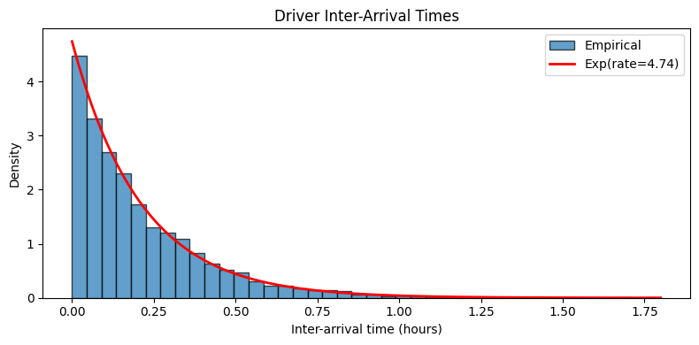

### Driver Shift Lengths

BoxCar assumption: Once a driver becomes available, the driver stays available for a random time which is uniformly distributed between 5 and 8 hours and then goes offline.

Examining the sample data, it looks instead that drivers stay available for a uniform random time between 6 and 8 hours.

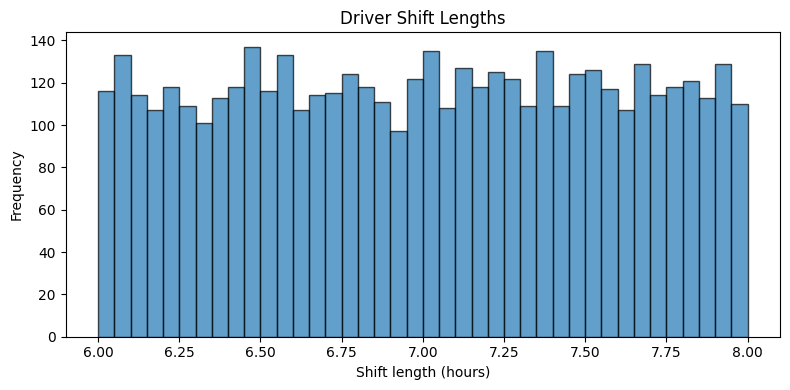

$H_0$: the drivers' shift lengths follow a uniform(6, 8) distribution

$H_a$: the drivers' shift lengths do not follow a uniform(6, 8) distribution

Again, we performed a Chi-squared goodness of fit test, resulting in a test statistic T = 10.871, where T~$\chi^2_{18}$, with P(T>30.79072) = 0.8997613. Therefore, we do not have the evidence to reject the null hypothesis that drivers' shift lengths follow a uniform(6, 8) distribution.

### Driver Location

BoxCar assumption: the location where a driver becomes available is equally likely to be anywhere in Squareshire, i.e follows a uniform distribution.

$H_0$: Drivers' initial locations follow a uniform distribution across Squareshire

$H_a$: Drivers' initial locations are not uniformly distributed across Squareshire

On examining the data, the driver initial x and y coordinates look normally distributed, but are obviously truncated. For the simulation, we decided to fit a (non-truncated) bivariate normal distribution, by sample moments, resulting in a $N_{2}(\mu, \Sigma)$ distribution, with $\mu$ = [9.97391884 11.51331376] and $\Sigma$ = [[19.0502075 0] [0 18.8030244]], and reject the point if it fell outside of the service square.

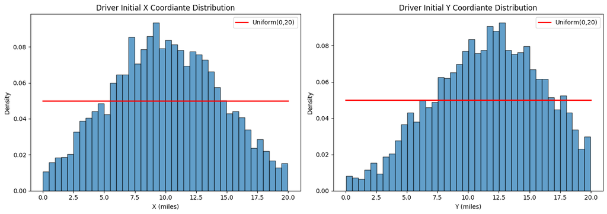

## 1.2 Rider Data

### Rider Inter-Arrival Times

BoxCar assumption, $H_0$: the riders arrive at random times to demand a taxi ride with an inter-arrival time of exponential(30/hour)

$H_a$: riders' inter-arrival times do not follow an exponential(30/hour) distribution

We performed a Kolmogorov-Smirnov test, with critical value 1.480, resulting in a test statistics T = 9.94. Therefore on the evidence of the sample data we would have to reject the null hypothesis, i.e. Boxcar's assumption.

The sample data looked broadly consistent with an exponential distribution, so we estimated the rate parameter and repeated our test.

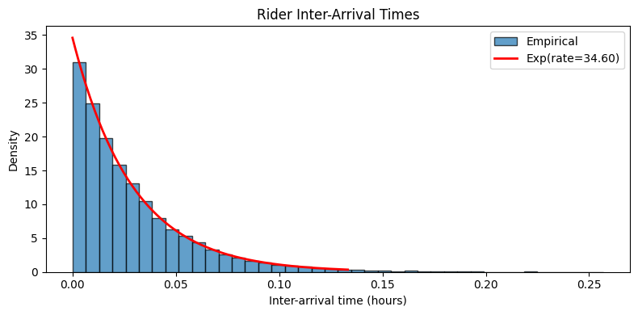

### Rider pickup and dropoff locations

BoxCar assumption, $H_0$: rider pickup and dropoff locations are independent of each other and uniformly distributed over Squareshire $H_a$: rider pickup and dropoff locations are either not independent or not uniformly distributed over Squareshire

We performed a serial test, having first divided Squareshire into a 5x5 grid for pickup locations and a 5x5 grid for dropoff locations, thereby giving 625 possible pickup x dropoff location combinations; resulting in a test statistics T = 58059.15, T~$\chi^2_{624}$, with P(T>58059.15) < 0.00001. Therefore, on the evidence of the sample data we would have to reject the null hypothesis, i.e. BoxCar's assumption.

Looking at the sample data, riders' pickup x coordinates, pickup y coordinates, dropoff x coordinates and dropoff y coordinates all look broadly normally distrubuted, but truncated. We tested the correlation of the four combinations of pickup/dropoff x and y coordinates.

Between drivers' pickup and dropoff x coordinates, T = -0.8979196, T~$t_{34419}$, with P(|T| > 0.8979196) = 0.3692347.

Between drivers' pickup and dropoff y coordinates, T = -1.287377, T~$t_{34419}$, with P(|T| > 1.287377) = 0.1979716.

Between drivers' pickup x coordinates and dropoff y coordinates, T = 1.203628, T~$t_{34419}$, with P(|T| > 1.203628) = 0.2287417.

Between drivers' pickup y coordinates and dropoff x coordinates, T = 0.4404503, T~$t_{34419}$, with P(|T| > 0.4404503) = 0.6596138.

Therefore, from the sample data, it appears that rider pickup and dropoff locations are independent, and can thereby be estimated separately.

For the simulation, for rider pickup and dropoff locations, we decided to fit a (non-truncated) bivariate normal distribution, by sample moments. Resulting in a $N_{2}(\mu, \Sigma)$ distirbution for pickup locations, with $\mu$ = [ 8.35968618 12.31754869] and $\Sigma$ = [[18.12253098 2.47169801] [ 2.47169801 17.55955499]], and a $N_{2}(\mu, \Sigma)$ distribution for dropoff locations, with $\mu$ = [11.22966234 13.26257015] and $\Sigma$ = [[20.6026483 2.20583431] [ 2.20583431 17.38054007]]. Again, we rejected the point if it fell outside the service square.

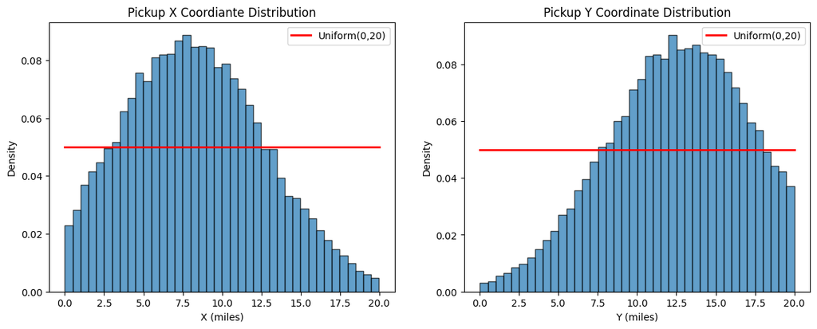

### 1.3 Trip Distances and Durations

BoxCar assumption: The length of a trip depends on the Euclidean distance between points, d. It is assumed that the average speed is approximately 20mph and the actual trip time is uniformly distributed between (0.8*d/20, 1.2*d/20)

We examined the scalar, actual trip time / (d/20), in the sample data and discovered that it took values (0.7, 1.3), implying that actual trip time in the sample data cannot be perturbed by a uniform(0.8, 1.2) random variable. We performed a chi-squared test to see if the scalar followed a uniform(0.7, 1.3) distribution.

$H_0$: actual trip time follows a uniform(0.7*d/20, 1.3*d/20) distribution $H_a$: actual trip time does not follow a uniform(0.7*d/20, 1.3*d/20) distribution

Out test statistic T = 31.23642, T~$\chi^2_{29}$, with P(T>31.23632) = 0.3543648. Therefore, we do not have the evidence from the sample data to reject the null hypothesis that actual trip time follows a uniform(0.7*d/20, 1.3*d/20) distribution.

## 1.4 Summary of Data vs Spec Parameters

| Parameter | BoxCar Assumption | Empirical (Data) |
| --- | --- | --- |
| Driver arrival rate | 3/hr | **4.74/hr** |
| Driver shift length | U[5, 8] hrs | **U[6, 8] hrs** |
| Driver initial location | Uniform | Truncated Bivariate Normal |
| Rider arrival rate | 30/hr | **34.6/hr** |
| Rider locations | Uniform | Truncated Bivariate Normal |
| Rider patience | Exp(5/hr) | ~0.81% abandon (consistent) |
| Avg trip distance | ~9.4 mi (theory for 20×20) | **8.16 mi** |
| Avg waiting time | — | **14.2 min** |
| Actual trip duration perturbation | Uniform(0.8, 1.2) | Uniform(0.7, 1.3) |

# 2. Simulation Model

We implement a discrete-event simulation engine with the following features:

- The simulation runs for 200 hours
- Rider arrivals with exponential inter-arrival times and exponential patience (abandonment if unmatched)
- Driver arrivals with exponential inter-arrival and uniform shift lengths; drivers go offline after their shift (finishing any current trip first)
- Closest-driver matching triggered whenever a new rider arrives or a driver becomes idle. Candidates include both idle and repositioning drivers (who are interruptible)
- Two-phase trips: pickup travel (driver→origin) then trip travel (origin→destination), both with travel time ~ U[0.8$\mu$, 1.2$\mu$] where $\mu$= distance/20 mph
- Fare: £3 base + £2/mile (origin→destination); Fuel: £0.20/mile for ALL miles driven
- Warm-up period to reach steady state (24 hours), and **multiple replications (100) for statistical validity

The logic of the model works as follows:

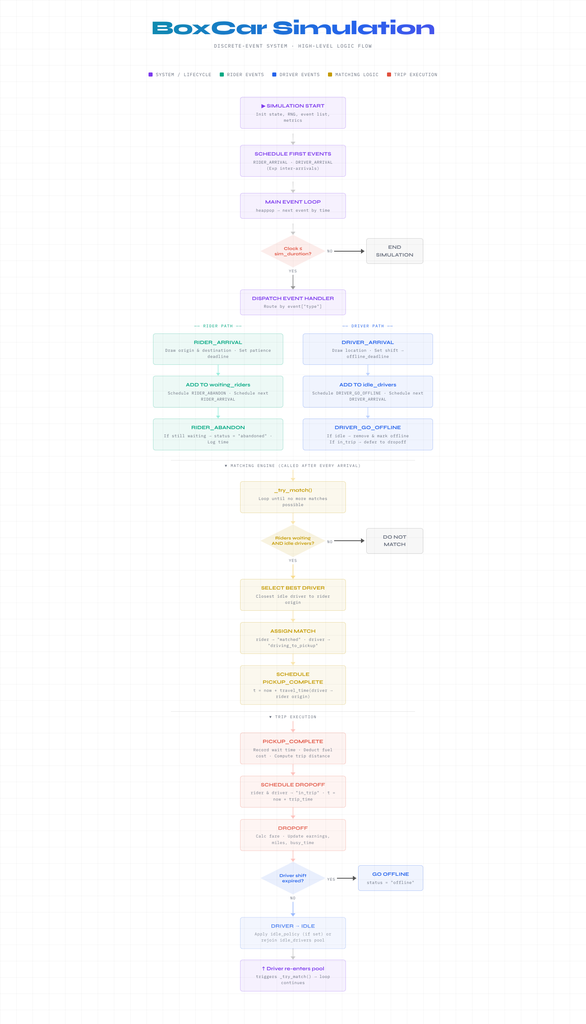

## 3. Examining baseline and calibrated scenario

```
Scenario                 Riders_served   Abandon%    AvgWait    P90Wait
------------------------------------------------------------------------
Baseline (spec)             3596.34       31.66%      31.2m      54.7m
Calibrated (data)           6027.66        1.01%      12.4m      25.4m
```

**Description of results**

```
Scenario                   Drivers   £/hr net   £/hr net std    Util%   Avg Trips / driver
------------------------------------------------------------------------------------------
Baseline (spec)             529.8      19.04         3.17       93.9%         6.6
Calibrated (data)           835.9      15.30         5.12       56.9%         7.1
```

Examining the above output, the rider abandon percentage appears implausibly high for the baseline secnario, indicating that either one or both of the driver and rider inter-arrival times assumptions provided by BoxCar do not accurately represent the underlying system. This is clearly a concern we should report back to BoxCar. In order to proceed to testing possible improvements whilst retaining the possiblity that BoxCar's remaining assumptions are sound, we opted to adjust the driver inter-arrival time and the rider inter-arrival time assumptions to match those estimated with the cut of operational data.

```
Scenario                 Riders_served   Abandon%    AvgWait    P90Wait
------------------------------------------------------------------------
Baseline (spec)             3596.34       31.66%      31.2m      54.7m
Baseline adjusted (data)    5477.19        9.89%      20.3m      43.5m
```

```
Scenario                   Drivers   £/hr net   £/hr net std    Util%   Avg Trips / driver
------------------------------------------------------------------------------------------
Baseline (spec)             529.8      19.04         3.17       93.9%         6.6
Baseline adjusted (data)    833.1      19.33         3.72       79.7%         6.4
```

As can be seen from the above comparison, making this change reduces the rider abandonment percentage substantially.

In the remainder of this report, 'Baseline adjusted (data)' refers to the spec assumptions with the driver and rider inter-arrival times changed to match those calibrated from the cut of data.

# Improvement Scenarios

We test four interventions to improve rider satisfaction while monitoring the trade-off with driver earnings:

1. **More drivers** — Increase driver arrival rate to 6/hr
2. **Longer shifts** — Extend shift range to U[7, 10] hours
3. **Weighted distance calc** - when matching a rider to a driver, we weight the euclidean distance between them by the relative proportion of each driver's shift that they've been non-idle
4. **Adaptive Ellipse ring idle policy** - idle drivers move to a coordinate on the map that's more likely to be closer to incoming rider locations

To provide clarity on what improvements 3. and 4. entail:

For improvement 3, at time $t$ in the simulation let $I_{t}$ be the set of idle drivers, and $B_{t,i}$, $i \in I_{t}$, be their proportional busy time (time they were driving a passenger / total time they've been on shift at time $t$), and let $K_{t}$ be the max{$B_{t, i}$, $i \in I_{t}$}, and let $d_{i}$, $i \in I_{t}$ = the distance between some rider freshly requesting a taxi at time $t$ and the idle drivers at time $t$. Then the weighted distance between said rider and driver $i$ is given by, $\frac{d_{i}B_{t, i}}{K_{t}}$, for all $i \in I_{t}$.

For improvement 4, when a driver finishes a trip, count n_active = number of idle drivers + repositioning drivers; Compute n_active evenly-spaced homes around the 1-sd Mahalanobis ellipse of the pickup distribution (determined by BoxCar assumptions in Baseline adjusted case and by the sample data in the Calibrated case); assign the driver to the closest available home slot; if the driver's locations is already within 0.25 miles of the slot, the driver stays put and does not waste fuel; otherwise, begin the driver beings repositioning, but remain **interruptible** (if a rider request arrives and this driver is closest, they divert mid-journey to the pickup instead)

To help visualise what improvement 4 looks like when implemented (for the calibrated data)

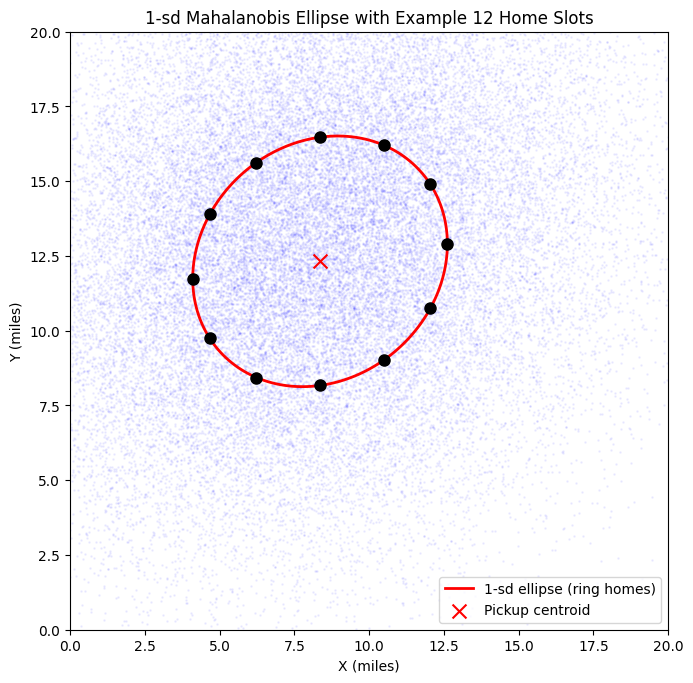

Baseline adjusted results, figures drawn from across 100 simulations:

```
Scenario                 Riders_served   Abandon%    AvgWait    P90Wait
------------------------------------------------------------------------
Baseline adjusted            5477.19        9.89%      20.3m      43.5m
More drivers (MD) (6/hr)     6007.54        1.24%      11.6m      23.8m
Longer shifts U[7,10]        6020.92        1.04%      11.1m      22.7m
Weighted distance (WD)       5436.85       10.54%      23.3m      47.3m
AdaptiveRingPolicy (ARP)     5582.33        8.00%      17.0m      36.5m
WD + ARP                     5484.73        9.75%      20.9m      43.2m
MD + ARP                     6021.56        1.00%      10.6m      20.3m
MD + WD + ARP                5982.55        1.52%      15.6m      34.9m
```

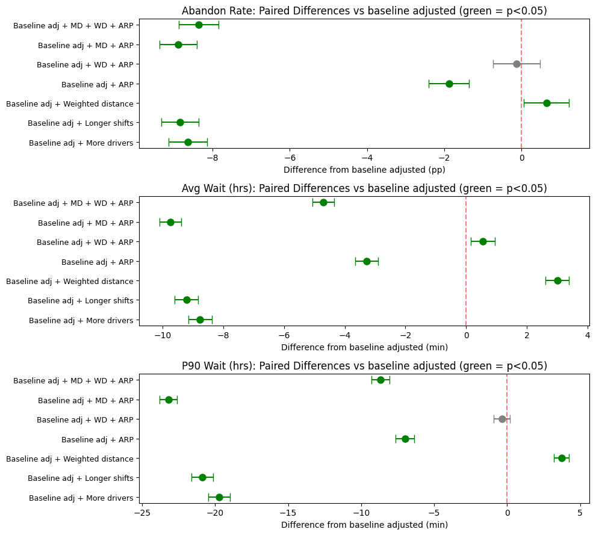

Increasing the number of available drivers or increasing the length of drivers' shifts results in a statistically significant improvement in rider experience compared with the baseline adjusted scenario. Abandonment drops to ~1%, average rider wait time drops to ~11 minutes, and the 90th percentile of the rider waiting times distribution across simulations drops to ~23 minutes.

Unsurprisingly given that it's primarily targeted to improve fairness among drivers, weighting the distance calculation results in a statistically significantly degraded rider experience.

```
Scenario                   Drivers   £/hr net   £/hr net std    Util%   Avg Trips / driver
------------------------------------------------------------------------------------------
Baseline adjusted           833.1      19.33         3.72       79.7%         6.4
More drivers (MD) (6/hr)   1060.8      17.42         4.75       59.0%         5.5
Longer shifts U[7,10]       837.7      17.10         4.42       57.4%         7.0
Weighted distance (WD)      835.5      18.88         3.42       83.3%         6.4
AdaptiveRingPolicy (ARP)    839.7      19.39         3.81       76.0%         6.5
WD + ARP                    833.0      18.89         3.44       81.0%         6.5
MD + ARP                   1053.4      17.13         4.56       58.3%         5.6
MD + WD + ARP              1052.2      16.66         3.72       65.1%         5.6
```

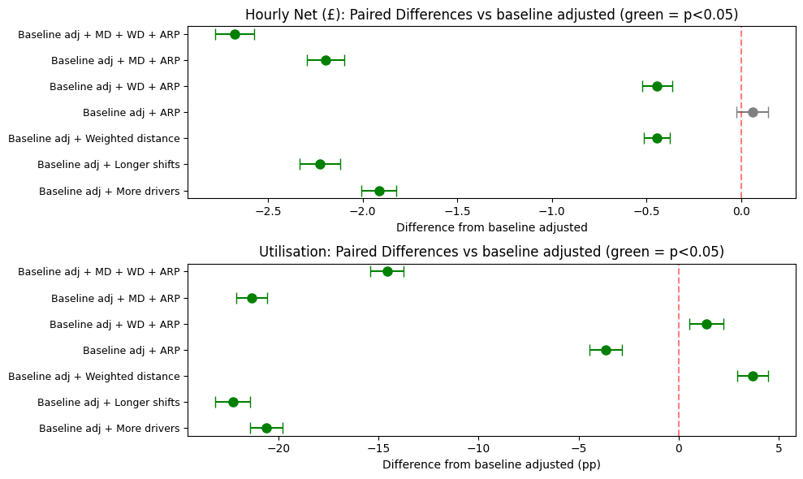

Intuitively, increasing the number of drivers or the length of drivers' shifts leads to a statistically significant reduction in driver earnings: more drivers share the same level of demand, which highlights a clear trade‑off between rider satisfaction and driver income.

Weighting the distance calculation results in a slight, statistically significant, reduction in hourly earnings but does increase fairness among drivers, indicated by the reduction in the standard deviation of driver eanings across simulations.

Allowing drivers to reposition results in a marginal increase in driver earnings (non-significant), but a corresponding reduction in fairness among drivers.

Regarding driver rest time, the utilization precentage represents the proportion of their total shifts that drivers were busy across simulations. Our highest utilization percentage comes from the weighted distance scenario, at 83.3%. Considering a stereotypical work day of 8 hours with a 1 hour break for lunch would result in a hypothetical utilization of 87.5%, a utilization of 83.3% does not appear excessive. Furthermore, it is conceivable that while driver's would prefer to have adquate time for breaks, they would not want to be idle for an excessive duration of their shift. Without further - targeted - guidance from BoxCar in this regard, it is difficult, and likely unprofitable, to suggest that a reduction in utilization is unambiguously desirable.

Key:

B: Baseline adjusted  
MD: More drivers (6/hour)  
LS: Longer shifts (U[7, 10])  
WD: Weighted Distance calculation  
ARP: Adaptive ring driver relocation policy  
Combined: More drivers, weighted distance calculation and adaptive ring driver relocation policy

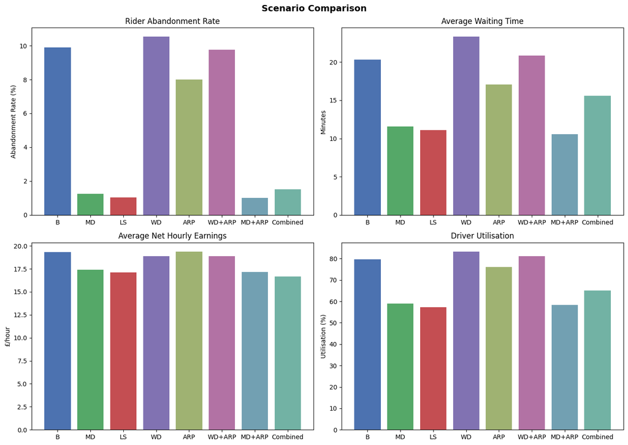

Calibrated data results:

```
Scenario                 Riders_served   Abandon%    AvgWait    P90Wait
------------------------------------------------------------------------
Calibrated (data)           6027.66        1.01%      12.4m      25.4m
More drivers (MD) (6/hr)    6080.68        0.03%      10.3m      21.2m
Longer shifts U[7,10]       6075.65        0.09%      11.0m      22.7m
Weighted distance (WD)      6016.87        0.92%      13.8m      29.3m
AdaptiveRingPolicy (ARP)    6045.28        0.59%       7.6m      15.2m
WD + ARP                    6051.46        0.55%       9.8m      21.7m
MD + ARP                    6092.82        0.01%       6.1m      12.0m
MD + WD + ARP               6085.23        0.02%       9.3m      21.1m
```

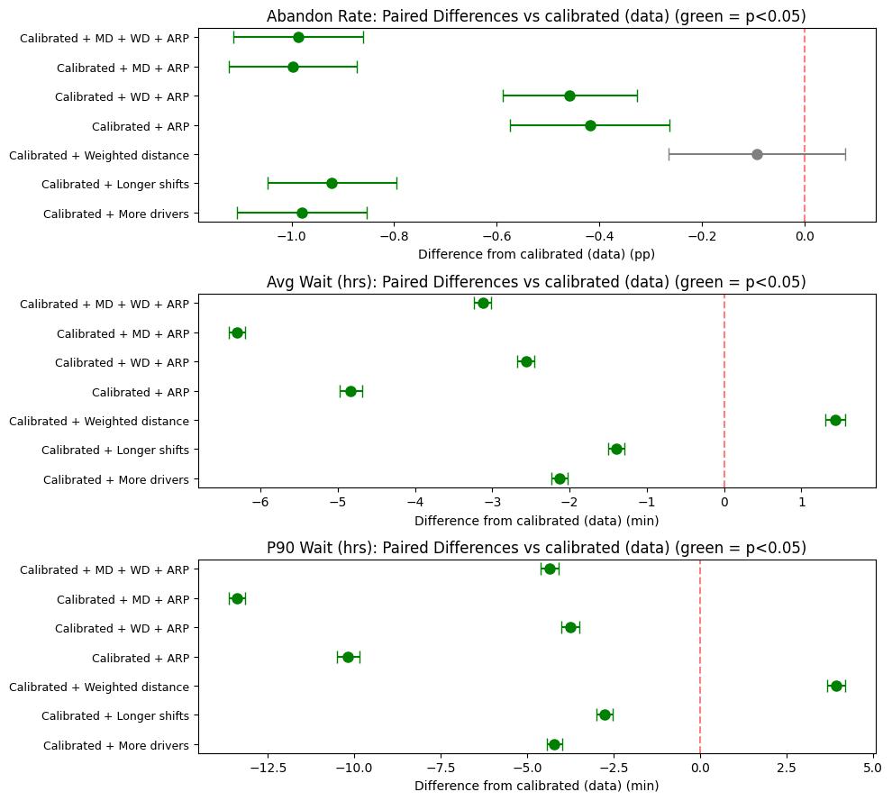

Increasing the number of available drivers or increasing the length of drivers' shifts results in a statistically significant reduction in key rider metrics, and hence an improved rider experience. Abandonment drops to ~0%, average rider wait time drops to ~11 minutes, and the 90th percentile of the rider waiting times distribution across simulations drops to ~22 minutes, which is an improvement over the calibrated scenario, if a marginal one.

As for the baseline scenarios, weighting the distance calculation results in a degraded rider experience, with a significant increase in average wait time.

```
Scenario                   Drivers   £/hr net   £/hr net std    Util%   Avg Trips / driver
------------------------------------------------------------------------------------------
Calibrated (data)           835.9      15.30         5.12       56.9%         7.1
More drivers (MD) (6/hr)   1061.6      12.41         5.64       43.0%         5.6
Longer shifts U[7,10]       833.9      13.00         5.41       46.2%         7.1
Weighted distance (WD)      839.7      15.12         3.77       59.1%         7.0
AdaptiveRingPolicy (ARP)    833.3      15.12         4.35       49.4%         7.1
WD + ARP                    835.3      14.92         3.22       53.4%         7.1
MD + ARP                   1057.5      12.14         4.45       37.6%         5.6
MD + WD + ARP              1060.2      11.89         2.85       41.9%         5.6
```

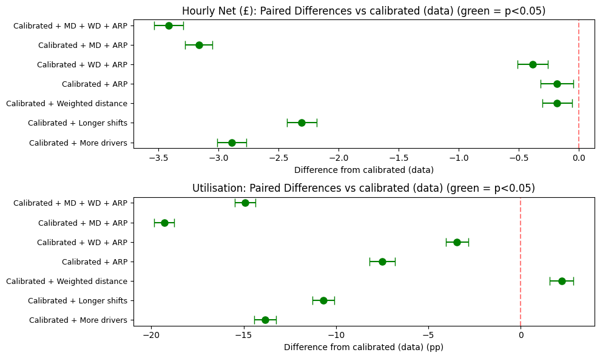

Again, increasing the number of drivers or the length of drivers' shifts leads to a statistically significant reduction in driver earnings and increases the difference in earnings, thereby increasing unfairness among drivers.

Weighting the distance calculation results in a slight reduction in hourly earnings (statistically significant) but does lead to a substantial increase in fairness among drivers, indicated by the reduction in the standard deviation in hourly earnings.

Allowing drivers to reposition results in a marginal decrease in driver earnings (statistically significant), but improves fairness among drivers.

Regarding driver rest time, as with the baseline adjusted scenarios, the highist utilization percentage comes from the weighted distance scenario, at 59.1%. Again considering the example of a stereotypical workday resulting in a utilization of 87.5%, this does not seem excessive, meaning the drivers have ample rest time.

On balance, the best driver experience comes from a combination of weighting the distance calculations and the adaptive ring policy, with a slight reduction in average driver hourly net salary (statistically significant) but a significant reduction in its standard deviation, thereby indicating a significant improvement in fairness in pay across drivers.

Key:

C: Calibrated from sample data  
MD: More drivers (6/hour)  
LS: Longer shifts (U[7, 10])  
WD: Weighted Distance calculation  
ARP: Adaptive ring driver relocation policy  
Combined: More drivers, weighted distance calculation and adaptive ring driver relocation policy

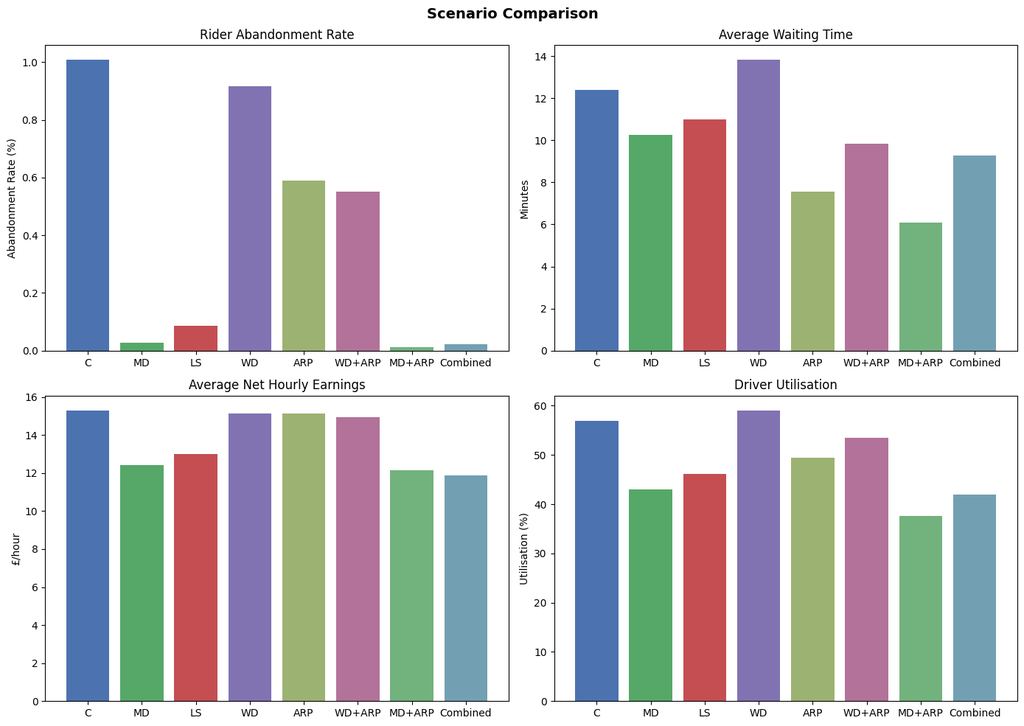

# Conclusions and Recommendations

The underlying system assumptions derived from the cut of sample data diverge substantially from those provided by BoxCar. We should confirm with BoxCar whether or not the sample has been drawn from a period of atypical system behaviour, and if not, should seek further clarification that might help explain the departure, possibly from further business intelligence BoxCar could provide.

BoxCar's assumptions regarding driver supply and rider demand lead to an implausibly high abandonment rate (31.66%). We should raise this with BoxCar and confirm whether or not it is appropriate to use the sample derived distributions for driver inter-arrival and rider inter-arrival times.

Regarding the proposed improvements starting from the calibrated sample data assumptions, again, the best rider experience results from a combination of including more drivers and the adaptive ring driver relocation policy, and the best driver experience results from weighting the distance calculations and the adaptive ring relocation policy.

Given improvement criteria are being evaluated within the context of a multi-objective optimization problem, with demonstrably conflicting objectives, to target possible changes more effectively we should ask BoxCar if there are service targets they want to meet at a minimum. For example, clearly it is better if rider abandonment rates and waiting times are lower, but are there performance targets, such as rider abandonment percentage being <1% and average rider wait times being under 10 minutes, that we can use to benchmark possible improvements, and thereby suggest improvements which provide an acceptable middle ground.

Finally, we have only run 100 simulations, and should likely increase this number substantially to deliver more robust results when some of the above concerns have been dealt with.